# Final Project

Data Science for Biologists, Spring 2021

Alex Bastardi

## Introduction

This data compiled statistics from different public schools in the country. The data is from data The Washington Post courtesy of Kate Rabinowitz, Laura Meckler, and Armand Emamdjomeh. Diversity was defined by the proportion of students in the dominant racial group. Diverse districts are places where fewer than 75 percent of students are of the same race. Undiverse districts are where 75 to 90 percent of students are the same race. In extremely undiverse districts one racial group constitutes more than 90 percent of students.

[School Diversity](https://raw.githubusercontent.com/rfordatascience/tidytuesday/master/data/2019/2019-09-24/school_diversity.csv)

```r
head(school_diversity)
```

```
## # A tibble: 6 x 15
##   LEAID LEA_NAME ST    d_Locale_Txt SCHOOL_YEAR   AIAN Asian  Black Hispanic
##   <chr> <chr>    <chr> <chr>        <chr>        <dbl> <dbl>  <dbl>    <dbl>
## 1 0100… alabama… AL    <NA>         1994-1995   0      0.589 71.7      0.196
## 2 0100… albertv… AL    town-distant 1994-1995   0      0.321  1.28     4.52
## 3 0100… albertv… AL    town-distant 2016-2017   0.294  0.551  3.19    46.7
## 4 0100… marshal… AL    rural-dista… 1994-1995   0.104  0.134  0.373    0.909
## 5 0100… marshal… AL    rural-dista… 2016-2017   0.492  0.299  1.07    21.3
## 6 0100… hoover … AL    city-small   1994-1995   0.0652 1.60   6.04     0.548
## # … with 6 more variables: White <dbl>, Multi <dbl>, Total <dbl>,
## #   diverse <chr>, variance <dbl>, int_group <chr>
```

```r
glimpse(school_diversity)
```

```
## Rows: 27,944
## Columns: 15
## $ LEAID        <chr> "0100002", "0100005", "0100005", "0100006", "0100006", "…
## $ LEA_NAME     <chr> "alabama youth services", "albertville city", "albertvil…
## $ ST           <chr> "AL", "AL", "AL", "AL", "AL", "AL", "AL", "AL", "AL", "A…
## $ d_Locale_Txt <chr> NA, "town-distant", "town-distant", "rural-distant", "ru…
## $ SCHOOL_YEAR  <chr> "1994-1995", "1994-1995", "2016-2017", "1994-1995", "201…
## $ AIAN         <dbl> 0.00000000, 0.00000000, 0.29373967, 0.10436857, 0.492350…
## $ Asian        <dbl> 0.5893910, 0.3207184, 0.5507619, 0.1341882, 0.2989274, 1…
## $ Black        <dbl> 71.7092338, 1.2828736, 3.1944189, 0.3727449, 1.0726218, …
## $ Hispanic     <dbl> 0.19646365, 4.52212957, 46.74132550, 0.90949754, 21.2941…
## $ White        <dbl> 27.504912, 93.874278, 46.778043, 98.479201, 75.804466, 9…
## $ Multi        <dbl> NA, NA, 2.441711, NA, 1.037454, NA, 4.089539, 4.300766, …
## $ Total        <dbl> 509, 3118, 5447, 6707, 5687, 7671, 13938, 10440, 1973, 2…
## $ diverse      <chr> "Diverse", "Extremely undiverse", "Diverse", "Extremely …
## $ variance     <dbl> NA, NA, 0.011556081, NA, NA, NA, 0.031555535, 0.00265660…
## $ int_group    <chr> NA, NA, "Highly integrated", NA, NA, NA, "Highly integra…
```

## Question 1

#### Is there a difference in the level of integration of schools between the school years 1994-1995 and 2016-2017?

### Methods

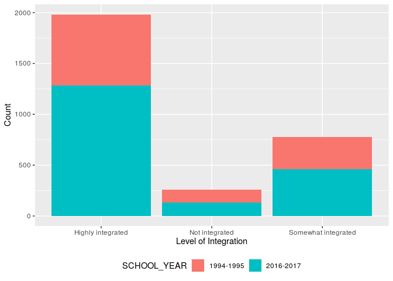

```r
school_diversity %>%
  select(ST, SCHOOL_YEAR, diverse, int_group) %>%
  drop_na() %>%
  ggplot() +
  geom_bar() +
  aes( x= int_group, fill=SCHOOL_YEAR) +
  scale_color_brewer(palette = "Set2") + #changing color palette
  theme(legend.position = "bottom") +
  labs(x= "Level of Integration", y= "Count")-> wrangle1 #moving the legend location
print(wrangle1)
```

### Answer

Yes it appears the school year 2016-2017 has more highly integrated districts than in 1994-1995. Not integrated districts remained relatively the same between the 2 school years.

## Question 2

#### For school districts in NJ and NY, does the white proportion of student population differ between school years 1994-1995 and 2016-2017?

### Methods

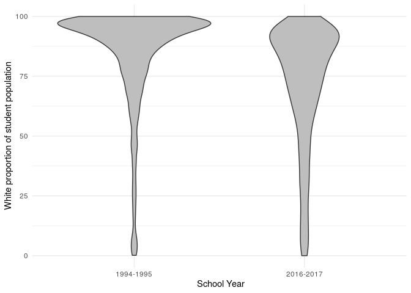

```r
school_diversity %>%
  filter( ST %in% c("NJ", "NY")) %>% #filtering states to NJ and NY
  select(ST, SCHOOL_YEAR, White) %>% #looking at only these 3 columns
  drop_na() %>%
  ggplot() +
  geom_violin(fill="grey") + #creating a violin plot
  aes(y= White, x=SCHOOL_YEAR) +
  theme_minimal() +
  labs( x=" School Year", y= "White proportion of student population")-> wrangle2
print(wrangle2)
```

### Answer

Yes, some school districts in NJ and NY had a lower white proportion of student population in 2016-2017 compared to 1994-1995.

## Question 3

### Methods

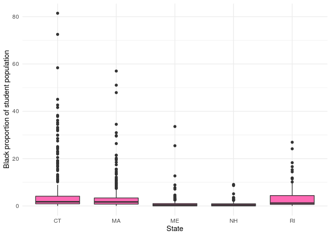

```r
school_diversity %>%
  filter( ST %in% c("CT", "ME", "MA", "NH", "RI")) %>% #filtering states to New England area
  ggplot() +
  geom_boxplot(fill= "hotpink") +
  aes(x= ST, y=Black) +
  theme_minimal() +
labs(x="State", y= "Black proportion of student population")-> wrangle3 #labeling plot
print(wrangle3)
```

### Answer

A school district in Connecticut has the highest Black proportion of student population.

## Question 4

#### In the Philadelphia metropolitan area (NJ, DE, PA), which state has the district with the highest Asian porportion of student population?

### Methods

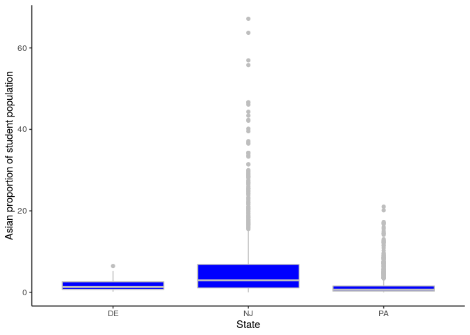

```r
school_diversity %>%
  filter( ST %in% c("PA", "NJ", "DE")) %>% #filtering states to philadelphia metropolitan area
  ggplot() +
  geom_boxplot(fill="blue", color="grey") + #changing color and fill to be aesthetically pleasing
  aes(x= ST, y=Asian) +
  theme_classic() +
  labs(x="State", y= "Asian proportion of student population") -> wrangle4
print(wrangle4)
```

### Answer

In the Philadelphia metropolitan area, NJ has the school district with the highest Asian proportion of student population.